# Assignment 2

Halan Badilla Osorio

```r
#Libraries
library(tidyverse)
library(ggplot2)
library(ggcorrplot)
library(caret)
library(MASS)
library(leaps)
library(glmnet)
```

# Problem 1:

Using a little bit of algebra, show that $p(x)= \frac{e^{\beta_0 +\beta_1x_1}}{1+e^{\beta_0+\beta_1x_1}}$ is equivalent to $\frac{p(X)}{1-p(X)} = e^{\beta_0+\beta_1x_1}$. In other words, the logistic function representation and logit representation for the logistic regression model are equivalent. Note, if you can’t see these equations, use your mouse to hover over them and they should pop up.

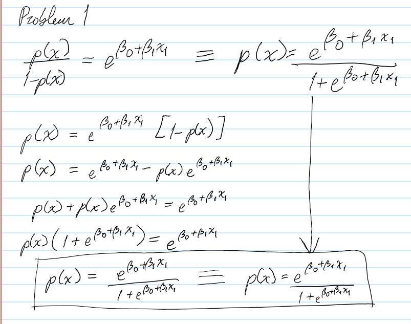

My work

# Solution:

# Problem 2:

Suppose we collect data for a group of students in a statistics class with variables X1 =hours studied, X2 =undergrad GPA, and Y = receive an A. We fit a logistic regression and produce estimated coefficient, β0 = −6, β1 = 0.05, β2 = 1. (a) Estimate the probability that a student who studies for 40 hours and has an undergrad GPA of 3.5 gets an A in the class.

2. How many hours would the student in part (a) need to study to have a 50% chance of getting an A in the class?

# Solution:

```r
# Betas
b0 <- -6
b1 <- 0.05
b2 <- 1

# Coefficients
x1 <- 40    # 40 hours studied
x2 <- 3.5   # Undergrad GPA

logReg1 <- b0 + (b1 * x1) + (b2 * x2)         # Logistic Regression
answerA <- exp(logReg1) / (1 + exp(logReg1))
print(answerA)
```

```
[1] 0.3775407
```

```r
p <- 0.5 # 50% chance

logReg2 <- log(p/(1-p)) # Applies the chance

answerB <- (logReg2 - b0 - (b2 * x2)) / b1

print(answerB)
```

```
[1] 50
```

# Problem 3:

14. In this problem, you will develop a model to predict whether a given car gets high or low gas mileage based on the *Auto* data set.
1. Create a binary variable, mpg01, that contains a 1 if mpg contains a value above its median, and a 0 if mpg contains a value below its median. You can compute the median using the median() function.

```r
auto <- read.csv("C:/Users/halan/Desktop/FPU2025Spring/Statistical Learning/Auto.csv")
mpgMedian <- median(auto$mpg)
auto <- auto %>%
  mutate(mpg01 = ifelse(mpg>=mpgMedian, 1, 0))
```

```r
auto
```

| mpg | cylinders | displacement | horsepower | weight | acceleration | year | origin | name | mpg01 |
| --- | --- | --- | --- | --- | --- | --- | --- | --- | --- |
| 18.0 | 8 | 307.0 | 130 | 3504 | 12.0 | 70 | 1 | chevrolet chevelle malibu | 0 |
| 15.0 | 8 | 350.0 | 165 | 3693 | 11.5 | 70 | 1 | buick skylark 320 | 0 |
| 18.0 | 8 | 318.0 | 150 | 3436 | 11.0 | 70 | 1 | plymouth satellite | 0 |
| 16.0 | 8 | 304.0 | 150 | 3433 | 12.0 | 70 | 1 | amc rebel sst | 0 |
| 17.0 | 8 | 302.0 | 140 | 3449 | 10.5 | 70 | 1 | ford torino | 0 |
| 15.0 | 8 | 429.0 | 198 | 4341 | 10.0 | 70 | 1 | ford galaxie 500 | 0 |
| 14.0 | 8 | 454.0 | 220 | 4354 | 9.0 | 70 | 1 | chevrolet impala | 0 |
| 14.0 | 8 | 440.0 | 215 | 4312 | 8.5 | 70 | 1 | plymouth fury iii | 0 |
| 14.0 | 8 | 455.0 | 225 | 4425 | 10.0 | 70 | 1 | pontiac catalina | 0 |
| 15.0 | 8 | 390.0 | 190 | 3850 | 8.5 | 70 | 1 | amc ambassador dpl | 0 |

[output cut: 387 more lines]

2. Explore the data graphically in order to investigate the association between mpg01 and the other features. Which of the other features seem most likely to be useful in predicting mpg01? Scatterplots and boxplots may be useful tools to answer this question. Describe your findings.

```r
# Getting rid of the name column and getting rid of the 5 rows with '?' in horsepower.
autoNumeric <- subset(auto, select = -name)
autoNumeric <- subset(autoNumeric, horsepower != '?')

# Viewing the dataset
view(autoNumeric)

# Transforming the horsepower to now be numeric
autoNumeric <- transform(autoNumeric, horsepower = as.numeric(horsepower))

# Doube checking that all the classes are actually numeric.
sapply(autoNumeric, class)
```

```
         mpg    cylinders displacement   horsepower       weight acceleration         year       origin
   "numeric"    "integer"    "numeric"    "numeric"    "integer"    "numeric"    "integer"    "integer"
       mpg01
   "numeric"
```

```r
# Numeric Correlation Matrix
cor(autoNumeric)
```

```
                    mpg  cylinders displacement horsepower     weight acceleration       year
mpg           1.0000000 -0.7776175   -0.8051269 -0.7784268 -0.8322442    0.4233285  0.5805410
cylinders    -0.7776175  1.0000000    0.9508233  0.8429834  0.8975273   -0.5046834 -0.3456474
displacement -0.8051269  0.9508233    1.0000000  0.8972570  0.9329944   -0.5438005 -0.3698552
horsepower   -0.7784268  0.8429834    0.8972570  1.0000000  0.8645377   -0.6891955 -0.4163615
weight       -0.8322442  0.8975273    0.9329944  0.8645377  1.0000000   -0.4168392 -0.3091199
acceleration  0.4233285 -0.5046834   -0.5438005 -0.6891955 -0.4168392    1.0000000  0.2903161
year          0.5805410 -0.3456474   -0.3698552 -0.4163615 -0.3091199    0.2903161  1.0000000
origin        0.5652088 -0.5689316   -0.6145351 -0.4551715 -0.5850054    0.2127458  0.1815277
mpg01         0.8369392 -0.7591939   -0.7534766 -0.6670526 -0.7577566    0.3468215  0.4299042
                 origin      mpg01
mpg           0.5652088  0.8369392
cylinders    -0.5689316 -0.7591939
displacement -0.6145351 -0.7534766
horsepower   -0.4551715 -0.6670526
weight       -0.5850054 -0.7577566
acceleration  0.2127458  0.3468215
year          0.1815277  0.4299042
origin        1.0000000  0.5136984
mpg01         0.5136984  1.0000000
```

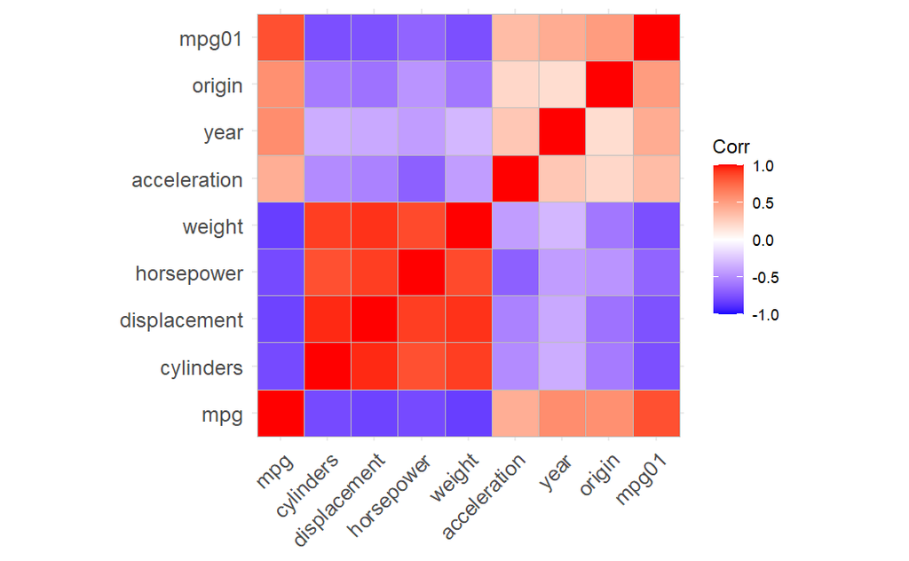

```r
# Cool Visual Correlation Matrix that you showed us.
corr <- round(cor(autoNumeric), 5)
ggcorrplot(corr)
```

Going off the correleation matrix, the best bet to predict MPG01 are the negative correlation ones, amount of cylinders, displacement, horsepower, and weight.

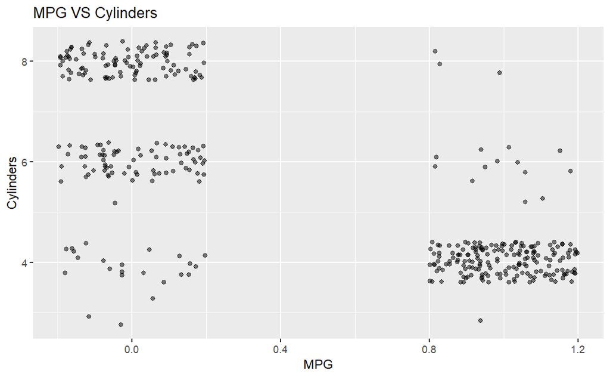

```r
# Scatterplot Negative Correlation
ggplot(autoNumeric, aes(x = mpg01, y = cylinders)) +
  geom_jitter(width = 0.2, alpha = 0.5) +
  labs(title="MPG VS Cylinders", x="MPG", y="Cylinders")
```

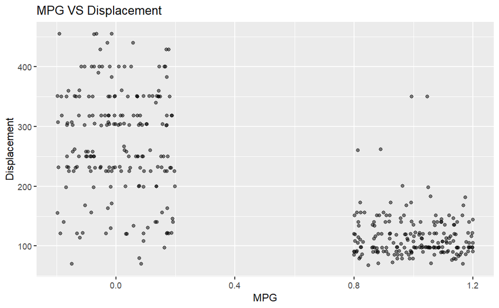

```r
ggplot(autoNumeric, aes(x = mpg01, y = displacement)) +
  geom_jitter(width = 0.2, alpha = 0.5) +
  labs(title = "MPG VS Displacement", x = "MPG", y = "Displacement")
```

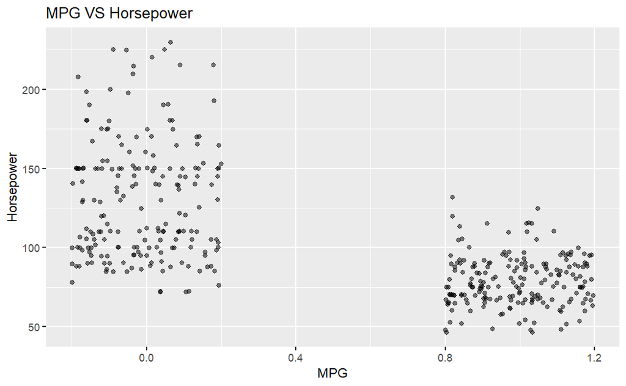

```r
ggplot(autoNumeric, aes(x = mpg01, y = horsepower)) +
  geom_jitter(width = 0.2, alpha = 0.5) +
  labs(title="MPG VS Horsepower", x="MPG", y="Horsepower")
```

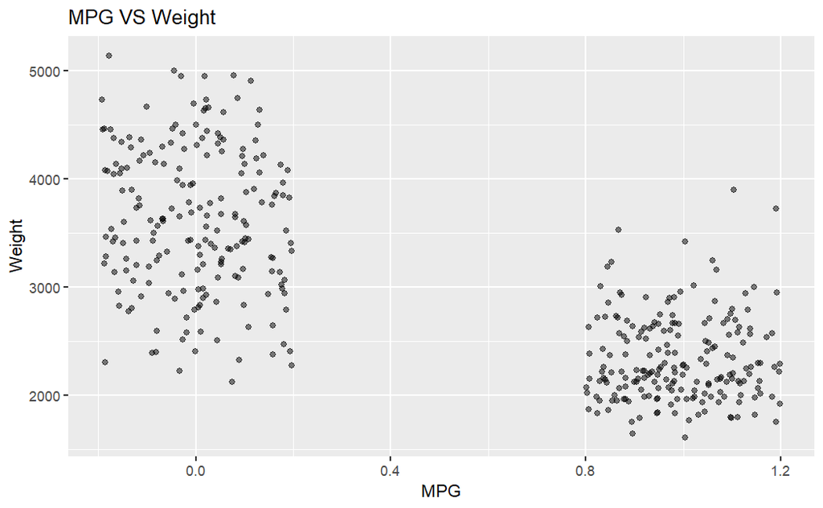

```r
ggplot(autoNumeric, aes(x = mpg01, y = weight)) +
  geom_jitter(width = 0.2, alpha = 0.5) +
  labs(title = "MPG VS Weight", x = "MPG", y = "Weight")
```

Furthermore, looking at the negative correlation scatterplots you can see the general trend that anything that if the MPG is above the median then it will generally be on the lower side. Lower amount of cylinders, less displacement, less horsepower and less weight all contribute to having a MPG that is generally higher than the median.

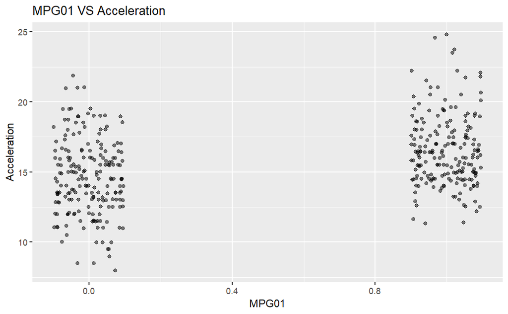

```r
# Scatterplot Positive Correlation
ggplot(autoNumeric, aes(x = mpg01, y = acceleration)) +
  geom_jitter(width = 0.1, alpha = 0.5) +
  labs(title="MPG01 VS Acceleration", x="MPG01", y="Acceleration")
```

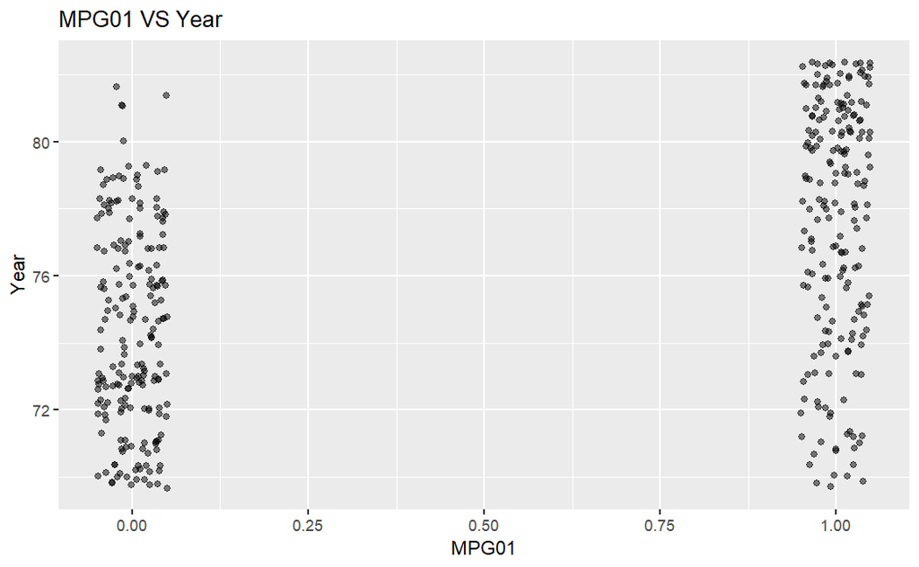

```r
ggplot(autoNumeric, aes(x = mpg01, y = year)) +
  geom_jitter(width = 0.05, alpha = 0.5) +
  labs(title = "MPG01 VS Year", x = "MPG01", y = "Year")
```

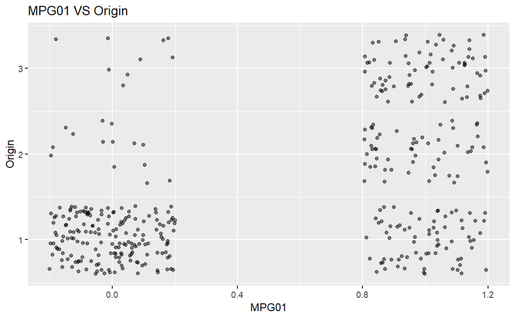

```r
ggplot(autoNumeric, aes(x = mpg01, y = origin)) +
  geom_jitter(width = 0.2, alpha = 0.5) +
  labs(title="MPG01 VS Origin", x="MPG01", y="Origin")
```

Analyzing the scatterplot for the positive correlation, given that these correlations are less comparitively to the negative ones, some change in the jitter allows you to see the grouping better and there is some sort of slight correlation. Those with higher acceleration and later years (80s+) are more likely to be above the median. Regarding the origins, the plot is very dense for anything below the median and is very likely to be from Origin 1. For anything above, it seems much more likely to be an even split with it being generally much more likely to be from either Origin 1, 2 and 3, with maybe slightly more in favor of Origin 1.

```r
autoNumeric$mpg01 <- as.factor(autoNumeric$mpg01)
```

```r
autoNumeric
```

|  | mpg | cylinders | displacement | horsepower | weight | acceleration | year | origin | mpg01 |
| --- | --- | --- | --- | --- | --- | --- | --- | --- | --- |
| 1 | 18.0 | 8 | 307.0 | 130 | 3504 | 12.0 | 70 | 1 | 0 |
| 2 | 15.0 | 8 | 350.0 | 165 | 3693 | 11.5 | 70 | 1 | 0 |
| 3 | 18.0 | 8 | 318.0 | 150 | 3436 | 11.0 | 70 | 1 | 0 |
| 4 | 16.0 | 8 | 304.0 | 150 | 3433 | 12.0 | 70 | 1 | 0 |
| 5 | 17.0 | 8 | 302.0 | 140 | 3449 | 10.5 | 70 | 1 | 0 |
| 6 | 15.0 | 8 | 429.0 | 198 | 4341 | 10.0 | 70 | 1 | 0 |
| 7 | 14.0 | 8 | 454.0 | 220 | 4354 | 9.0 | 70 | 1 | 0 |
| 8 | 14.0 | 8 | 440.0 | 215 | 4312 | 8.5 | 70 | 1 | 0 |
| 9 | 14.0 | 8 | 455.0 | 225 | 4425 | 10.0 | 70 | 1 | 0 |
| 10 | 15.0 | 8 | 390.0 | 190 | 3850 | 8.5 | 70 | 1 | 0 |

[output cut: 382 more lines]

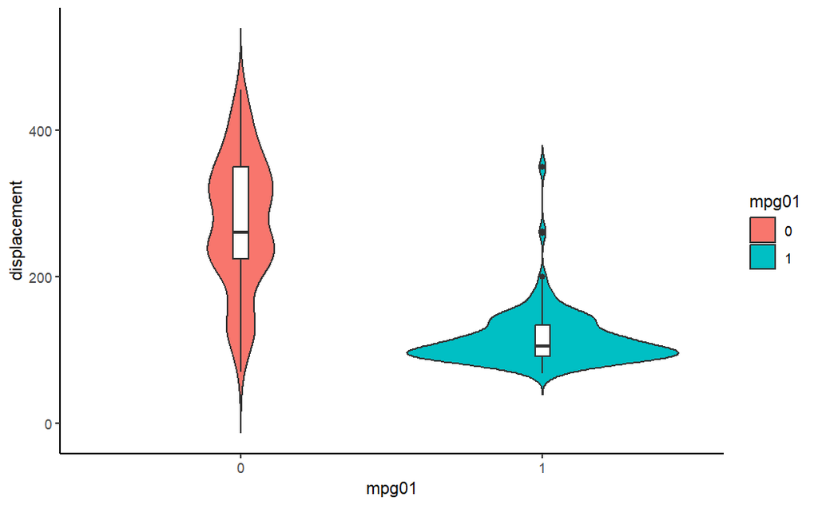

```r
# Violin Plot to show Density in Negative
ggplot(autoNumeric, aes(x = mpg01, y = displacement, fill = mpg01)) +
  geom_violin(trim=FALSE) +
  geom_boxplot(width = 0.05, fill = 'white') +
  theme_classic()
```

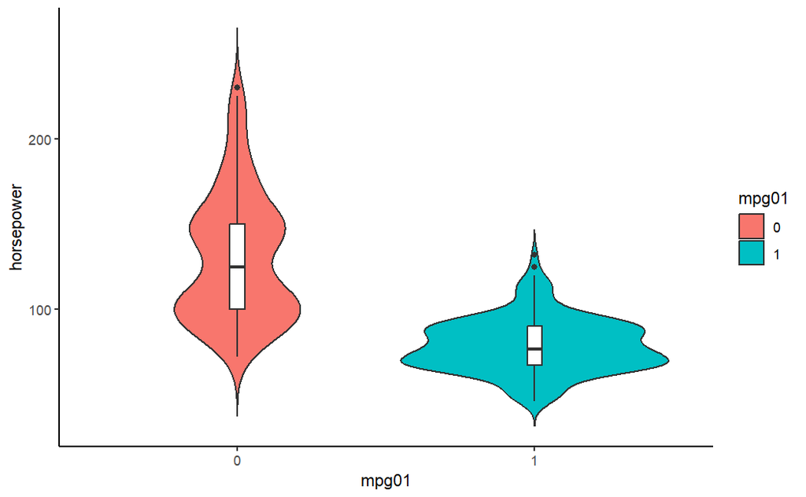

```r
ggplot(autoNumeric, aes(x = mpg01, y = horsepower, fill = mpg01)) +
  geom_violin(trim=FALSE) +
  geom_boxplot(width = 0.05, fill = 'white') +
  theme_classic()
```

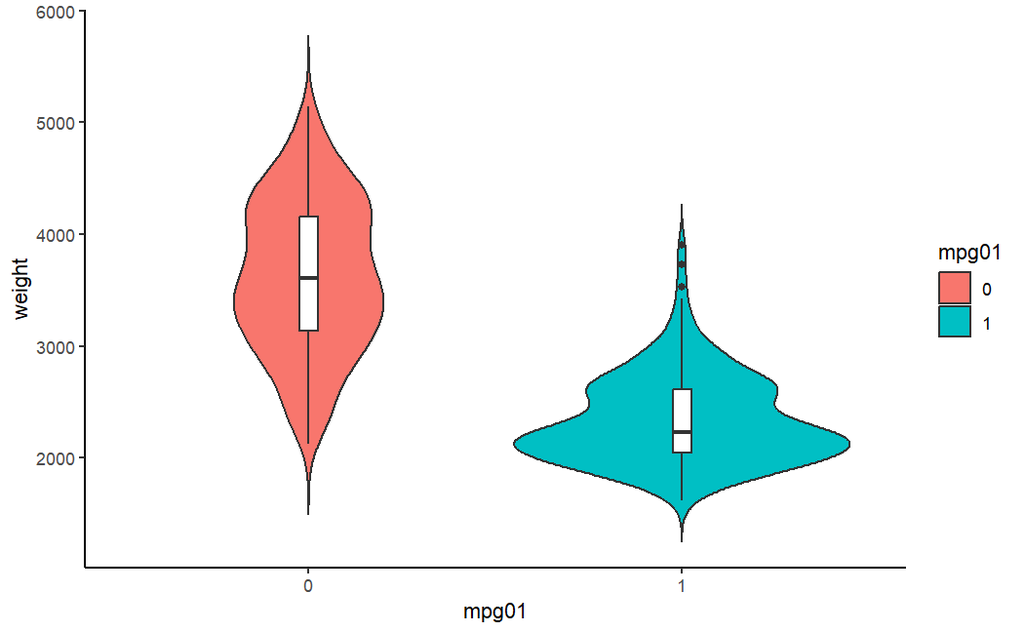

```r
ggplot(autoNumeric, aes(x = mpg01, y = weight, fill = mpg01)) +
  geom_violin(trim=FALSE) +
  geom_boxplot(width = 0.05, fill = 'white') +
  theme_classic()
```

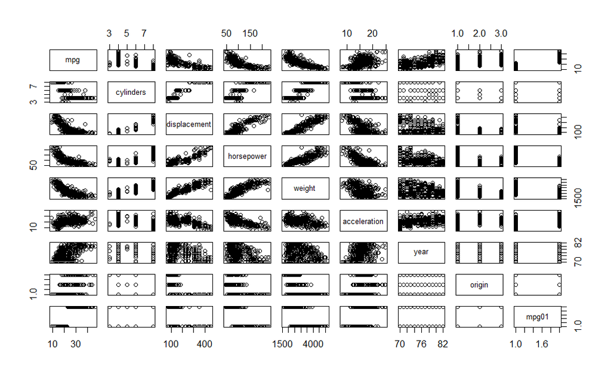

```r
#autoNumeric <- autoNumeric[,-9]

pairs(autoNumeric)
```

The pairs shows a clear correlation between mpg, displacement, horsepower, weight and acceleration. All similar things to what the correlation matrix showed.

3. Split the data into a training set and a test set.

```r
# Split into training and test data.
set.seed(1)

train <- createDataPartition(autoNumeric$mpg01, p = .70, list = FALSE)

training <- autoNumeric[train, ] # 70% used for training
testing <- autoNumeric[-train, ] # Remaining used for testing
```

4. Perform LDA on the training data in order to predict mpg01 using the variables that seemed most associated with mpg01 in (b). What is the test error of the model obtained?

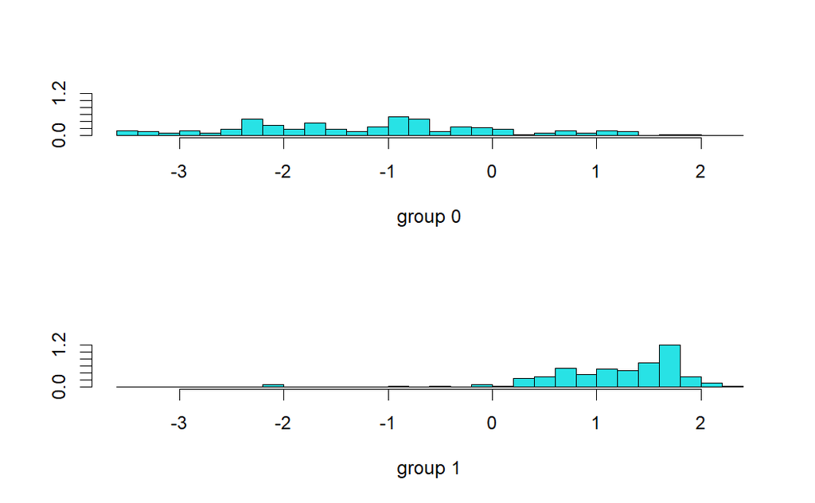

```r
# Perform LDA on training Data to predict mpg01.
ldaAN <- lda(mpg01 ~ displacement + horsepower + weight + acceleration, data = training)

ldaPredictions <- predict(ldaAN, newdata = testing)

plot(ldaAN)
```

```r
ldaTestError <- mean(ldaPredictions$class != testing$mpg01)

print(ldaTestError)
```

```
[1] 0.112069
```

5. Perform QDA on the training data in order to predict mpg01 using the variables that seemed most associated with mpg01 in (b). What is the test error of the model obtained?

```r
# Perform QDA
qdaAN <- qda(mpg01 ~ displacement + horsepower + weight + acceleration, data = training)

qdaPredictions <- predict(qdaAN, newdata = testing)

qdaTestError <- mean(qdaPredictions$class != testing$mpg01)

print(qdaTestError)
```

```
[1] 0.09482759
```

I’d like to mention I had to redo this like 4 times because every time I did it the LDA and QDA were identical. I thought I had done something incorrectly, no, I was just simply very unlucky.

6. Perform logistic regression on the training data in order to predict mpg01 using the variables that seemed most associated with mpg01 in (b). What is the test error of the model obtained?

# Solution:

```r
# Log Regression
autoLog <- glm(mpg01 ~ displacement + horsepower + weight + acceleration, data = training, family = binomial)
logPredictions <- predict(autoLog, newdata = testing, type = "response")
probPredictions <- ifelse(logPredictions > 0.5, 1, 0)
logTestError <- mean(probPredictions != testing$mpg01)

print(logTestError)
```

```
[1] 0.112069
```

# Problem 4:

We now review k-fold cross-validation.

1. Explain how k-fold cross-validation is implemented.
2. What are the advantages and disadvantages of k-fold cross-validation relative to:
   1. The validation set approach?
   2. LOOCV? Best possible results as it goes through ALL of the potential combinations. LOOCV is an extreme case of k-fold where k = n. The downside to this is that this is the most computationally intensive as it gets exponentially more intensive the more sets of data that exist.

# Solution:

1. K-fold will divide the dataset into k amount of equal parts and then train the model k-1 amount of times, each time excluding 1 fold which will be the validation test. All the results need to be averaged and then you find the average across all the folds.
2. Validation Set:

   There is never a crossover between training and testing set. A big advantage is that the validation set is much easier to run but has higher variance whereas kfold is more computationally intensive as it needs to do many iterations more times and as such reduces variance.

   LOOCV:

   kFold is faster than LOOCV and that’s due to LOOCV being a form of kFold, specifically, the best variation. However, the downside is that in LOOCV k = n so k always runs the max amount of times. As such, it is even more so, MUCH more computationally extensive than kFold generally as everytime another n is added the runtime goes up exponentially. That is the biggest drawback, it does have higher variance but it has much lower bias as it gets tested on literally everything. This generally results in LOOCV being the better outcome since you are guaranteed to get the most optimal combination at the cost of computational power.

# Problem 5:

From the data in [Miscellaneous Datasets](http://www.stat.ufl.edu/~winner/datasets.html) , obtain the data on “Fibre Diameters and Breaking Strenghs for Nextel 610 Fibres.” (please note that there is a typo on the website. It should be Strength and not Strengh). According to the description available there, the expectation is that the log of breaking strength of the fibre should be negatively and linearly related to diameter. (Note log here means natural log if not specified.)

1. Produce a scatter plot of breaking strength against diameter.
2. Produce a scatter plot of the log of breaking strength against diameter.
3. Produce a scatter plot of the log of breaking strength against the log of diameter.
4. Regress breaking strength on diameter.
5. Regress the log of breaking strength on diameter.
6. Regress the log of breaking strength on the log of diameter.

# Solution:

```r
strengths <- read_table("https://users.stat.ufl.edu/~winner/data/fiber_weibull.dat", col_names = FALSE)
```

```r
summary(strengths)
```

```
 Break Strength    Diameter
 Min.   :2399   Min.   :10.50
 1st Qu.:2834   1st Qu.:10.93
 Median :3072   Median :11.30
 Mean   :3077   Mean   :11.31
 3rd Qu.:3300   3rd Qu.:11.60
 Max.   :4185   Max.   :12.70
```

[figure not shown]

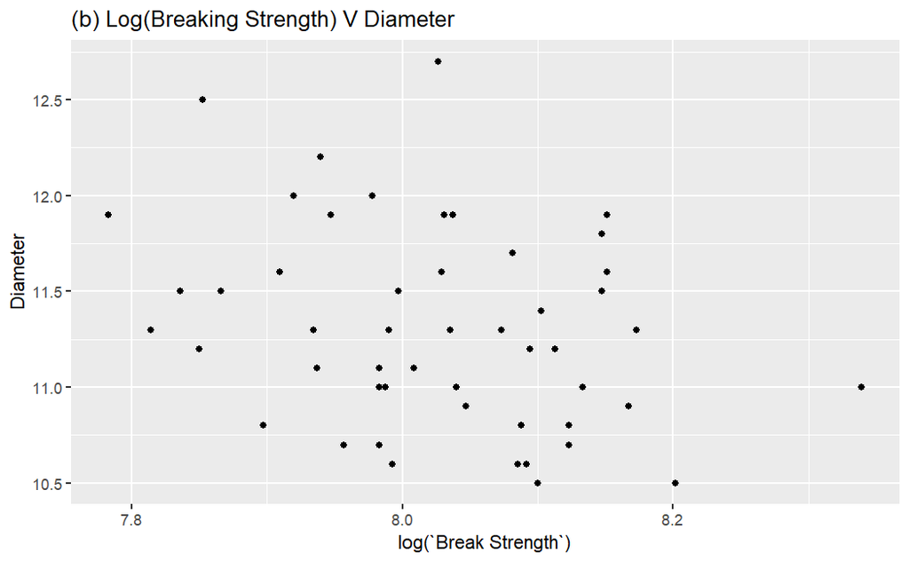

```r
ggplot(strengths, aes(log(`Break Strength`), Diameter)) +
  geom_point() +
  labs(title = "(b) Log(Breaking Strength) V Diameter")
```

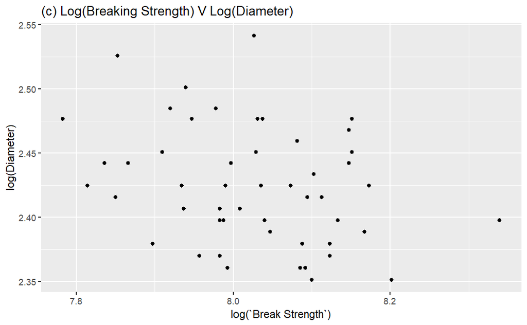

```r
ggplot(strengths, aes(log(`Break Strength`), log(Diameter))) +
  geom_point() +
  labs(title = "(c) Log(Breaking Strength) V Log(Diameter)")
```

```r
summary(regressA)
```

```
Call:
lm(formula = `Break Strength` ~ Diameter, data = strengths)

Residuals:
    Min      1Q  Median      3Q     Max
-603.46 -246.10   -6.76  223.64 1047.22

Coefficients:
            Estimate Std. Error t value   Pr(>|t|)
(Intercept)  5312.78    1040.41   5.106 0.00000561 ***
Diameter     -197.73      91.91  -2.151     0.0365 *
---
Signif. codes:  0 ‘***’ 0.001 ‘**’ 0.01 ‘*’ 0.05 ‘.’ 0.1 ‘ ’ 1

Residual standard error: 335.7 on 48 degrees of freedom
Multiple R-squared:  0.08794,   Adjusted R-squared:  0.06894
F-statistic: 4.628 on 1 and 48 DF,  p-value: 0.03651
```

```r
summary(regressB)
```

```
Call:
lm(formula = log(`Break Strength`) ~ Diameter, data = strengths)

Residuals:
      Min        1Q    Median        3Q       Max
-0.211992 -0.075119  0.003561  0.076367  0.293763

Coefficients:
            Estimate Std. Error t value            Pr(>|t|)
(Intercept)  8.76091    0.33575  26.094 <0.0000000000000002 ***
Diameter    -0.06504    0.02966  -2.193              0.0332 *
---
Signif. codes:  0 ‘***’ 0.001 ‘**’ 0.01 ‘*’ 0.05 ‘.’ 0.1 ‘ ’ 1

Residual standard error: 0.1083 on 48 degrees of freedom
Multiple R-squared:  0.09105,   Adjusted R-squared:  0.07211
F-statistic: 4.808 on 1 and 48 DF,  p-value: 0.0332
```

```r
regressC <- lm(log(`Break Strength`) ~ log(Diameter), strengths)

summary(regressC)
```

```
Call:
lm(formula = log(`Break Strength`) ~ log(Diameter), data = strengths)

Residuals:
     Min       1Q   Median       3Q      Max
-0.21123 -0.07610  0.00396  0.07673  0.29398

Coefficients:
              Estimate Std. Error t value             Pr(>|t|)
(Intercept)     9.8328     0.8209  11.978 0.000000000000000499 ***
log(Diameter)  -0.7454     0.3385  -2.202               0.0325 *
---
Signif. codes:  0 ‘***’ 0.001 ‘**’ 0.01 ‘*’ 0.05 ‘.’ 0.1 ‘ ’ 1

Residual standard error: 0.1083 on 48 degrees of freedom
Multiple R-squared:  0.09174,   Adjusted R-squared:  0.07282
F-statistic: 4.848 on 1 and 48 DF,  p-value: 0.03251
```

# Problem 6:

From the data in [Miscellaneous Datasets](http://www.stat.ufl.edu/~winner/datasets.html) , obtain the data on “Variables associated with Permeability and Porosity of Rocks”

1. Fit a multiple regression model to predict porosity. Please provide a clean model with only significant variables. Interpret your model results and diagnostics.
2. Fit a multiple regression model to predict log(permeability). Please provide a clean model with only significant variables. Interpret your model results and diagnostics.